# FORECASTING FINAL PROJECT

### 3.2.2 **Key Takeaway**:

This visualization highlights the **importance of tuning changepoint hyperparameters** in time-series forecasting. While the original model identifies **many trend shifts**, leading to a **highly adaptive but volatile forecast**, the adjusted model **limits trend changes**, producing a **smoother and more interpretable forecast**. The selection of the best model depends on whether the goal is to **capture short-term variations or prioritize long-term stability** in forecasting construction spending.

## 3.3 Assessment of the model

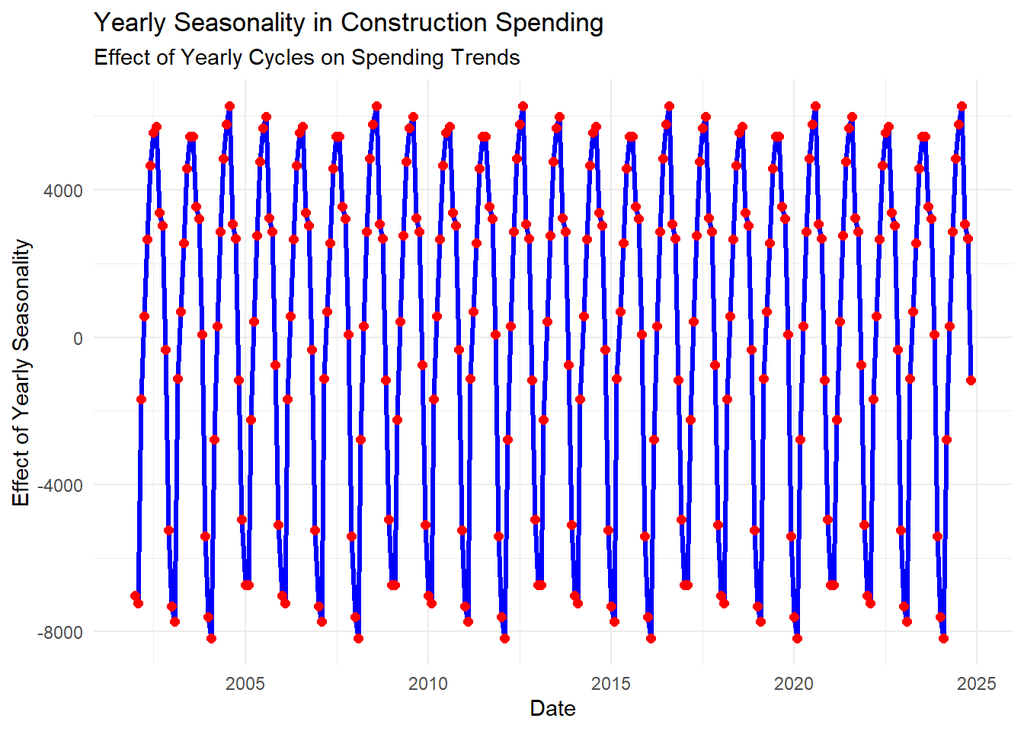

```r
# Load required libraries
library(tidyverse)
library(tsibble)
library(fable)
library(fable.prophet)
library(lubridate)

# Load the dataset
construction_data <- read.csv("construction_spending.csv") %>%
  mutate(date = ymd(date)) %>%
  arrange(date) %>%
  as_tsibble(index = date)

# Fit the Prophet model with yearly seasonality
prophet_model <- construction_data %>%
  model(
    prophet = fable.prophet::prophet(construction_spending ~
                                      growth("linear") +
                                      season(period = "year"))  # Include only yearly seasonality
  )

# Extract components from the Prophet model
prophet_components <- prophet_model %>% components()

# Extract only yearly seasonality from components
yearly_seasonality <- prophet_components %>%
  as_tibble() %>%
  select(date, year)

# Plot yearly seasonality
ggplot(yearly_seasonality, aes(x = date, y = year)) +
  geom_line(color = "blue", linewidth = 1.2) +
  geom_point(color = "red", size = 2) +
  labs(title = "Yearly Seasonality in Construction Spending",
       subtitle = "Effect of Yearly Cycles on Spending Trends",
       x = "Date",
       y = "Effect of Yearly Seasonality") +
  theme_minimal()
```

The graph illustrates the **yearly seasonality** component of the Prophet model for **construction spending**. The **blue line** represents the yearly fluctuations in spending, while the **red dots** highlight key points in the cycle. The y-axis captures the magnitude of seasonal effects, showing peaks and troughs in spending over each year.

### 3.3.1 **Key Observations:**

1. **Regular Seasonal Patterns:** The graph shows consistent **yearly cycles**, indicating strong seasonality in construction spending. Spending tends to **increase during certain months and decrease in others**, following a predictable pattern.
2. **Magnitude of Seasonality:** The fluctuations range significantly, with seasonal effects reaching peaks above **4,000** and troughs below **-8,000**, suggesting **strong seasonality**.
3. **Stability Over Time:** The pattern remains relatively stable over time, meaning that **historical seasonal trends continue into the future**.
4. **Interpretation for Forecasting:** Since seasonality is pronounced, including **yearly seasonal adjustments in the Prophet model is crucial** to improve forecast accuracy.

This plot confirms that **yearly cycles have a significant impact** on construction spending, and any forecasting model should **account for these seasonal variations** to avoid under- or overestimations in future predictions.

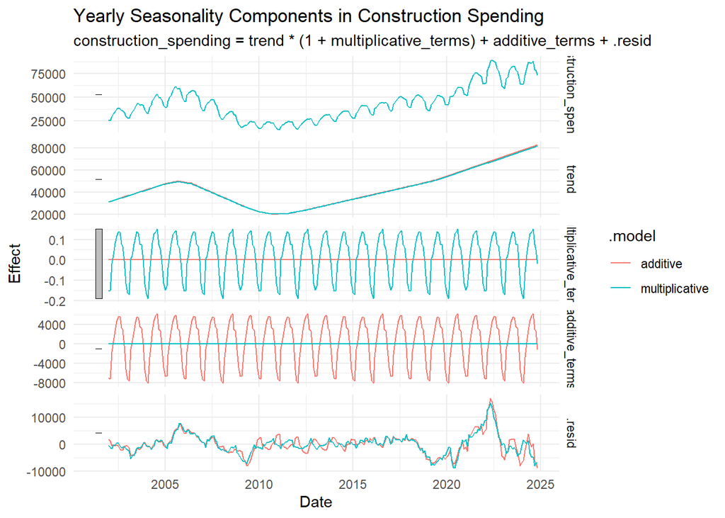

```r
# Load necessary libraries
library(tidyverse)
library(tsibble)
library(fable)
library(fable.prophet)
library(lubridate)

# Fit Prophet Model with only yearly seasonality
prophet_model <- construction_data %>%
  model(
    additive = fable.prophet::prophet(construction_spending ~
                season(period = "year", type = "additive")),
    multiplicative = fable.prophet::prophet(construction_spending ~
                season(period = "year", type = "multiplicative"))
  )

# Extract components for visualization
prophet_components <- prophet_model %>% components()

# Plot yearly seasonality components
autoplot(prophet_components) +
  labs(title = "Yearly Seasonality Components in Construction Spending",
       x = "Date",
       y = "Effect") +
  theme_minimal()
```

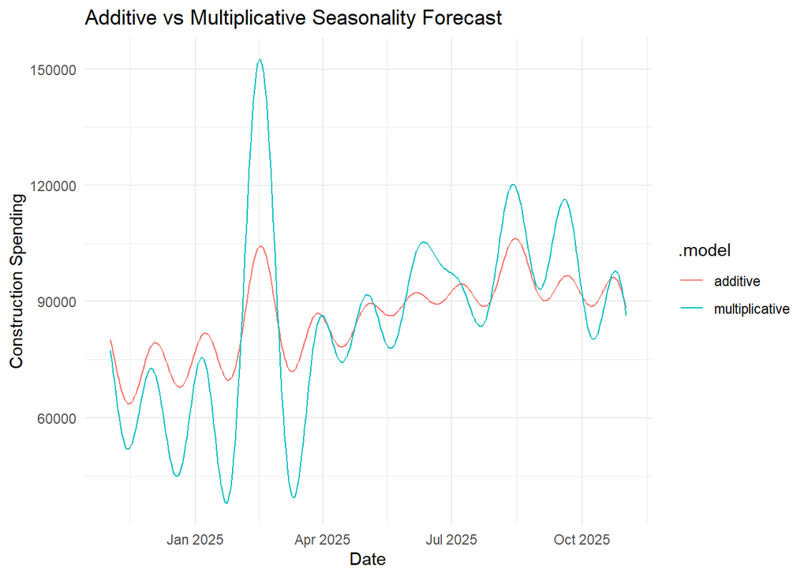

```r
# Forecast for one year ahead to compare additive vs multiplicative seasonality
forecast_comparison <- prophet_model %>%
  forecast(h = "1 year")

# Plot Forecast Comparison
autoplot(forecast_comparison, level = NULL) +
  labs(title = "Additive vs Multiplicative Seasonality Forecast",
       x = "Date",
       y = "Construction Spending") +
  theme_minimal()
```

#### 3.3.1.1 Interpretation

The two plots illustrate the impact of yearly seasonality on construction spending, comparing additive and multiplicative seasonal effects.

1. **First Plot: Yearly Seasonality Components in Construction Spending**  
   This visualization breaks down the construction spending trend into its core components: the overall trend, multiplicative seasonality, additive seasonality, and residual errors. The trend component shows a long-term upward trajectory in spending, while the seasonality components highlight the periodic fluctuations that occur on a yearly basis. The multiplicative seasonality exhibits stronger fluctuations in proportion to the trend, while the additive component remains relatively stable in its effect over time. The residual component captures unexplained variations, with noticeable spikes indicating periods of unexpected deviations.
2. **Second Plot: Additive vs. Multiplicative Seasonality Forecast**  
   This forecast comparison evaluates the impact of additive and multiplicative yearly seasonality on future spending projections. The multiplicative model (blue line) captures stronger fluctuations in high-spending periods, suggesting that seasonal effects intensify as spending increases. In contrast, the additive model (red line) maintains a relatively fixed seasonal impact regardless of trend magnitude. This indicates that the choice between additive and multiplicative seasonality depends on whether seasonal variations should scale with the overall trend. If spending patterns exhibit increasing seasonal deviations over time, the multiplicative model provides a better representation.

### 3.3.2 **Key Takeaways:**

- The multiplicative model is preferable when seasonal effects grow in magnitude as overall spending increases.
- The additive model is useful when seasonal effects remain consistent over time, irrespective of spending levels.
- The forecast shows that high-spending periods are more volatile under the multiplicative model, suggesting stronger seasonal dependency.
- The decision between additive and multiplicative seasonality depends on whether construction spending exhibits proportional or fixed seasonal variations.

This analysis provides insights into how seasonal factors influence future projections, helping refine the forecasting model based on real-world spending behavior.

# 4 Section 4

### 4.0.1 Rolling Window Cross-Validation for Model Comparison

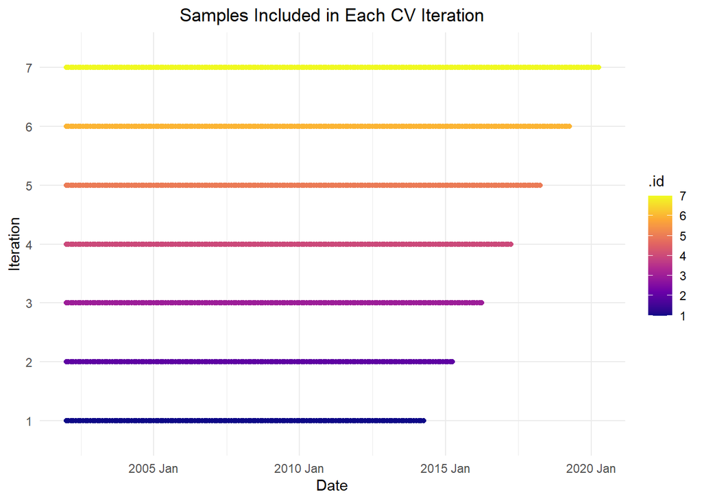

```r
# Load necessary libraries
library(tidyverse)
library(tsibble)
library(fable)
library(fable.prophet)
library(slider)

# Convert dataset to tsibble format with proper indexing
train_data <- train_data %>%
  mutate(date = yearmonth(date)) %>%
  distinct(date, .keep_all = TRUE) %>%
  as_tsibble(index = date)

test_data <- data_test %>%
  mutate(date = yearmonth(date)) %>%
  distinct(date, .keep_all = TRUE) %>%
  as_tsibble(index = date)

cv_folds_data <- data_train %>%
  stretch_tsibble(.init = 148, .step = 12)

# Visualize the samples included in each cross-validation iteration
cv_folds_data %>%
  ggplot() +
  geom_point(aes(x = date, y = factor(.id), color = .id)) +  # Continuous color scale
  scale_color_viridis_c(option = "plasma") +  # Better color scheme
  ylab("Iteration") +
  xlab("Date") +
  ggtitle("Samples Included in Each CV Iteration") +
  theme_minimal() +
  theme(
    plot.title = element_text(hjust = 0.5),
    plot.caption = element_text(hjust = 0.5)
  )
```

This plot illustrates the **cross-validation (CV) iterations** used in a **time series forecasting model**. Each horizontal line represents an **iteration** of the cross-validation process, with different colors corresponding to different training sets.